# Statistique Descriptive

Kossi Tonyi Wobubey ABOTSI

```r
library(readxl)
library(tidyverse)
```

### Importation des données :

```r
# install.packages("readxl")

# Load the readxl package


# Read data from the Excel file
data <- read_excel("données_complètes_9_classes_MEFG_stagiaire_tatistique.xlsx")

#Selection des colonnes utile
data = data  %>% select(collège:classe,`taille cm`: gender,sb:pmvpa,time,CA:`CSP mère`)

#Renommage des colonnes
colnames(data)[3:4] = c("taille_cm","weight_kg")
colnames(data)[22:23] = c("CSP_père","CSP_mère")

#Ajout de colonne des IMC
data$IMC_kg_m2 <- data$weight_kg / (data$taille_cm * 10^-2)^2

# Ajout d'une nouvelle colonne "IPS_categorie"
data$IPS_categorie <- ifelse(data$IPS < 89, "Faible",
                             ifelse(data$IPS >= 90 & data$IPS <= 114, "Moyenne", "Élevée"))

# Print the first few rows of the data to verify
head(data)
```

```
## # A tibble: 6 × 25
##   collège classe taille_cm weight_kg   age gender    sb   lpa   mpa   vpa psb
##   <chr>   <chr>      <dbl>     <dbl> <dbl> <chr>  <dbl> <dbl> <dbl> <dbl> <chr>
## 1 aigle   3P           157        55    15 F       26.3  4.83  21.2  2.33 47,88…
## 2 aigle   3P           178        61    14 M       14    8.33  28    4    25,45…
## 3 aigle   3P           170        75    15 M       20.3  7.33  21.8  5    36,97…
## 4 aigle   3P           153        68    15 F       26.2  7.33  18.7  2.83 47,58…
## 5 aigle   3P           181        95    15 M       12.2 12.3   22.3  6.17 22,12…
## 6 aigle   3P           164        51    15 F       20.5  6.5   20.3  4.83 37,27…
## # ℹ 14 more variables: pla <chr>, pmpa <chr>, pvpa <chr>, mvpa <dbl>,
## #   pmvpa <chr>, time <chr>, CA <dbl>, Activités <chr>, IPS <dbl>,
## #   Géographie <chr>, CSP_père <chr>, CSP_mère <chr>, IMC_kg_m2 <dbl>,
## #   IPS_categorie <chr>
```

### **Statistique descriptive de la Population**

- **Age selon le sexe**

```r
data_1 = as.data.frame(table(data$age,data$gender))

names(data_1) = c("age","sexe","Effectif_Participant")

data_1
```

```
##    age sexe Effectif_Participant
## 1   12    F                   17
## 2   13    F                   12
## 3   14    F                   18
## 4   15    F                   21
## 5   16    F                    1
## 6   17    F                    0
## 7   18    F                    1
## 8   12    M                   17
## 9   13    M                   19
## 10  14    M                   37
## 11  15    M                   16
## 12  16    M                    1
## 13  17    M                    1
## 14  18    M                    0
```

Mise en place d’un barplot pour visualiser le nombre de participant par age.

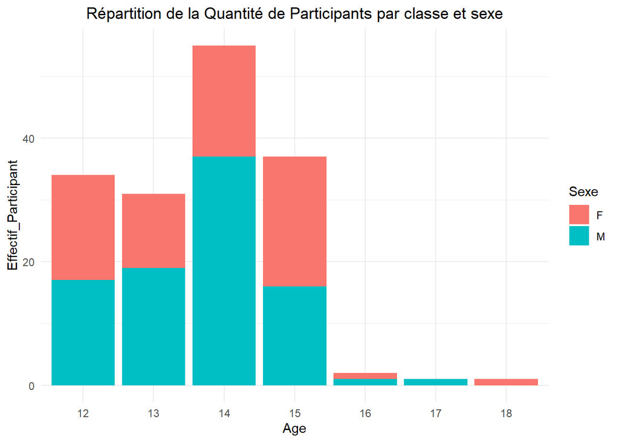

```r
# Créer le diagramme en barres empilées
ggplot(data_1, aes(x = age, y = Effectif_Participant, fill = sexe)) +
  geom_bar(stat = "identity") +
  labs(x = "Age", y = "Effectif_Participant", fill = "Sexe", title = "Répartition de la Quantité de Participants par classe et sexe") +
  theme_minimal() +
  theme(plot.title = element_text(hjust = 0.5))  # Centrer le titre
```

Dans cette observation, il est noté une prédominance de garçons âgés de 13 et 14 ans par rapport aux filles, tandis qu’il y a pratiquement autant de filles que de garçons âgés de 12 et 16 ans. De plus, il y a davantage de filles de 15 ans, tandis qu’il n’y a que des garçons de 17 ans et seulement des filles de 18 ans. On a une observation total de **161**.

- **IMC selon le sexe**

```r
data %>%
  group_by(gender) %>%
  summarise(IMC_tot = sum(na.omit(IMC_kg_m2)))
```

```
## # A tibble: 2 × 2
##   gender IMC_tot
##   <chr>    <dbl>
## 1 F        1416.
## 2 M        1874.
```

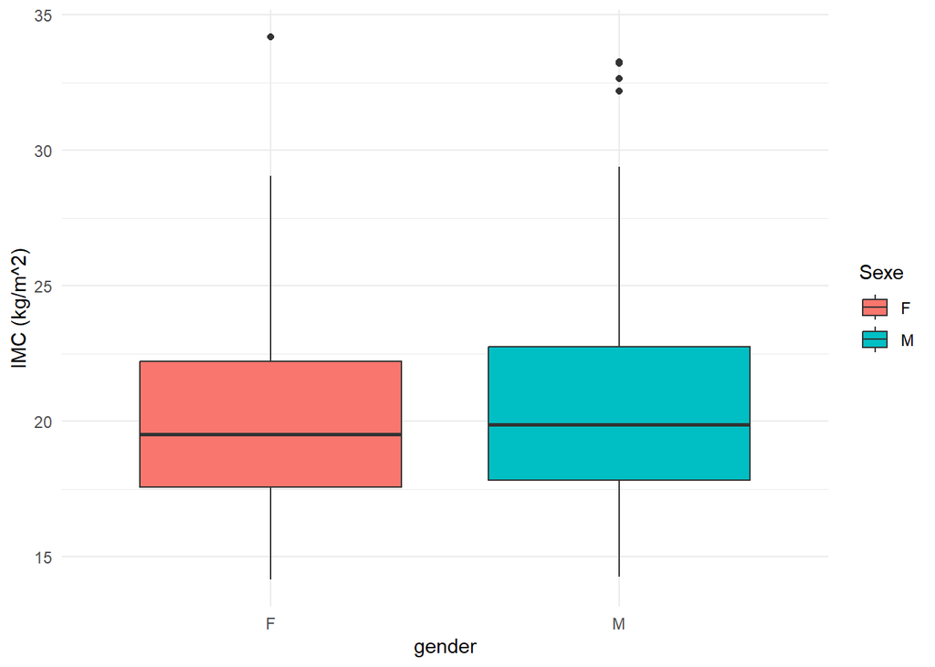

```r
# Créer le diagramme en boîte pour l'IMC par classe et sexe
ggplot(data, aes(x = gender, y = IMC_kg_m2, fill = gender)) +
  geom_boxplot() +
  labs(x = "gender", y = "IMC (kg/m^2)", fill = "Sexe") +
  theme_minimal()
```

En moyenne l’IMC des garçons est légèrement plus grand que celui des filles. Récapitulatif dans le tableau suivant :

|  | Population globale | Filles | Garçons |
| --- | --- | --- | --- |
| **IMC** | **3290.438** | **1416.073** | **1874.365** |

- **CSP du père**

```r
data_1 = as.data.frame(table(data$CSP_père,data$gender))
names(data_1) = c("CSP_père","sexe","Effectif_Participant")

data_1
```

```
##                                             CSP_père sexe Effectif_Participant
## 1           Artisans, commercants, chef d'entreprise    F                    8
## 2                                              Autre    F                    0
## 3  Cadres et professions intellectuelles supérieures    F                   12
## 4                                            Employé    F                   16
## 5                                            Ouvrier    F                    5
## 6                           Profession intermédiaire    F                   15
## 7                                           Retraité    F                    0
## 8                                      Sans activité    F                    6
## 9                                        Sans emploi    F                    1
## 10          Artisans, commercants, chef d'entreprise    M                   11
## 11                                             Autre    M                    2
## 12 Cadres et professions intellectuelles supérieures    M                   11
## 13                                           Employé    M                   27
## 14                                           Ouvrier    M                    9
## 15                          Profession intermédiaire    M                   24
## 16                                          Retraité    M                    1
## 17                                     Sans activité    M                    0
## 18                                       Sans emploi    M                    1
```

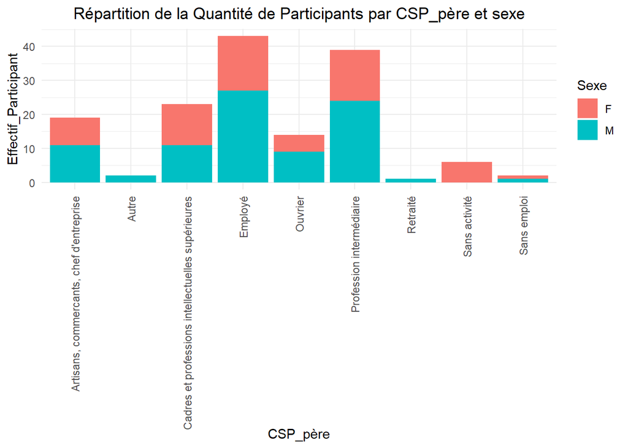

```r
# Créer le diagramme en barres empilées avec les modalités en abscisses affichées verticalement
ggplot(data_1, aes(x = CSP_père, y = Effectif_Participant, fill = sexe)) +
  geom_bar(stat = "identity") +
  labs(x = "CSP_père", y = "Effectif_Participant", fill = "Sexe", title = "Répartition de la Quantité de Participants par CSP_père et sexe") +
  theme_minimal() +
  theme(plot.title = element_text(hjust = 0.5), axis.text.x = element_text(angle = 90, vjust = 0.5, hjust = 1))  # Modifier l'angle des modalités sur l'axe x
```

Avec un total de **149** observation,Il est observé une prédominance des garçons dont le père exerce les professions d’artisans, commerçants, chefs d’entreprise, employés ou ouvriers par rapport aux filles. On constate également qu’il y a presque autant de filles que de garçons dont le père occupe des postes de cadres et professions intellectuelles supérieures, ainsi que chez ceux sans emploi. En revanche, on ne retrouve que des filles parmi les enfants dont le père est sans activité, et exclusivement des garçons parmi ceux dont le père est retraité ou exerce une autre profession.

- **CSP_mère**

```r
data_1 = as.data.frame(table(data$CSP_mère,data$gender))
names(data_1) = c("CSP_mère","sexe","Effectif_Participant")

data_1
```

```
##                                             CSP_mère sexe Effectif_Participant
## 1           Artisans, commercants, chef d'entreprise    F                    2
## 2                                              Autre    F                    3
## 3  Cadres et professions intellectuelles supérieures    F                    8
## 4                                            Employé    F                   19
## 5                                          Infirmier    F                    1
## 6                                            Ouvrier    F                    3
## 7                           Profession intermédiaire    F                   12
## 8                                      Sans activité    F                    5
## 9                                        Sans emploi    F                    2
## 10          Artisans, commercants, chef d'entreprise    M                   10
## 11                                             Autre    M                    1
## 12 Cadres et professions intellectuelles supérieures    M                    9
## 13                                           Employé    M                   33
## 14                                         Infirmier    M                    0
## 15                                           Ouvrier    M                    7
## 16                          Profession intermédiaire    M                   14
## 17                                     Sans activité    M                    3
## 18                                       Sans emploi    M                    0
```

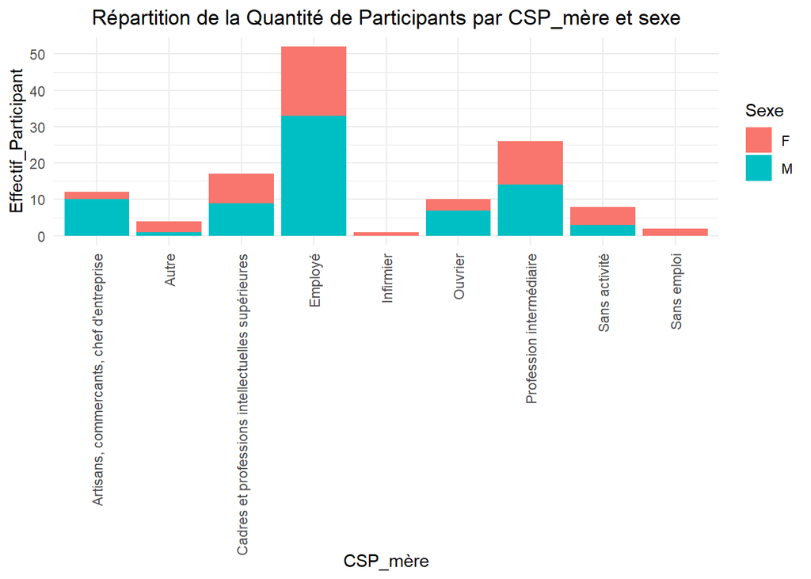

```r
# Créer le diagramme en barres empilées avec les modalités en abscisses affichées verticalement
ggplot(data_1, aes(x = CSP_mère, y = Effectif_Participant, fill = sexe)) +
  geom_bar(stat = "identity") +
  labs(x = "CSP_mère", y = "Effectif_Participant", fill = "Sexe", title = "Répartition de la Quantité de Participants par CSP_mère et sexe") +
  theme_minimal() +
  theme(plot.title = element_text(hjust = 0.5), axis.text.x = element_text(angle = 90, vjust = 0.5, hjust = 1))  # Modifier l'angle des modalités sur l'axe x
```

### Statistique descriptive pour le lieu d’étude :

- **Proportion de l’échantillon global de la population selon le CA**

```r
prop.table(table(data$CA))*100
```

```
##
##         1         2         3         4
##  9.937888 22.360248  8.074534 59.627329
```

[output not shown]

Illustration avec un barplot :

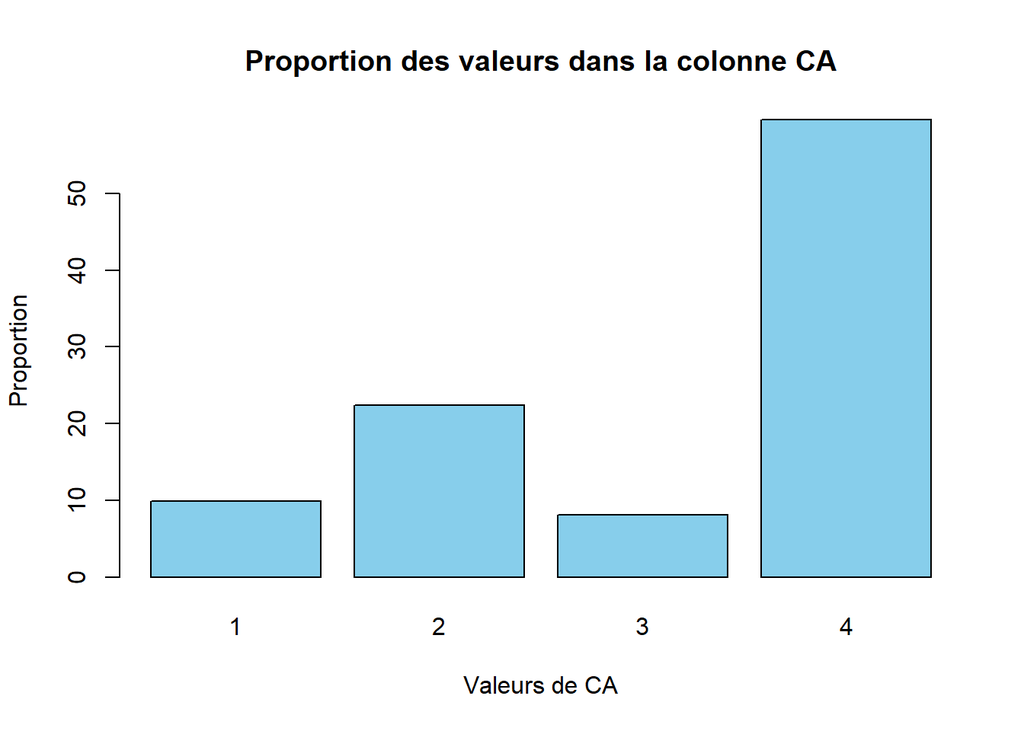

```r
barplot(prop.table(table(data$CA))*100, main = "Proportion des valeurs dans la colonne CA",
        xlab = "Valeurs de CA", ylab = "Proportion", col = "skyblue")
```

- **Proportion de l’échantillon global de la population selon l’IPS**

**-IPS faible inférieur à 89**

**-IPS moyenne entre 90 et 114**

**-IPS élevé supérieur à 115**

```r
prop.table(table(data$IPS_categorie))*100
```

```
##
##   Faible  Moyenne
## 22.36025 77.63975
```

| **IPS** | **Faible** | **Moyenne** | **Elevé** |
| --- | --- | --- | --- |
| **Proportion(%)** | 22.36 | 77.64 | 0 |

Illustration avec un barplot

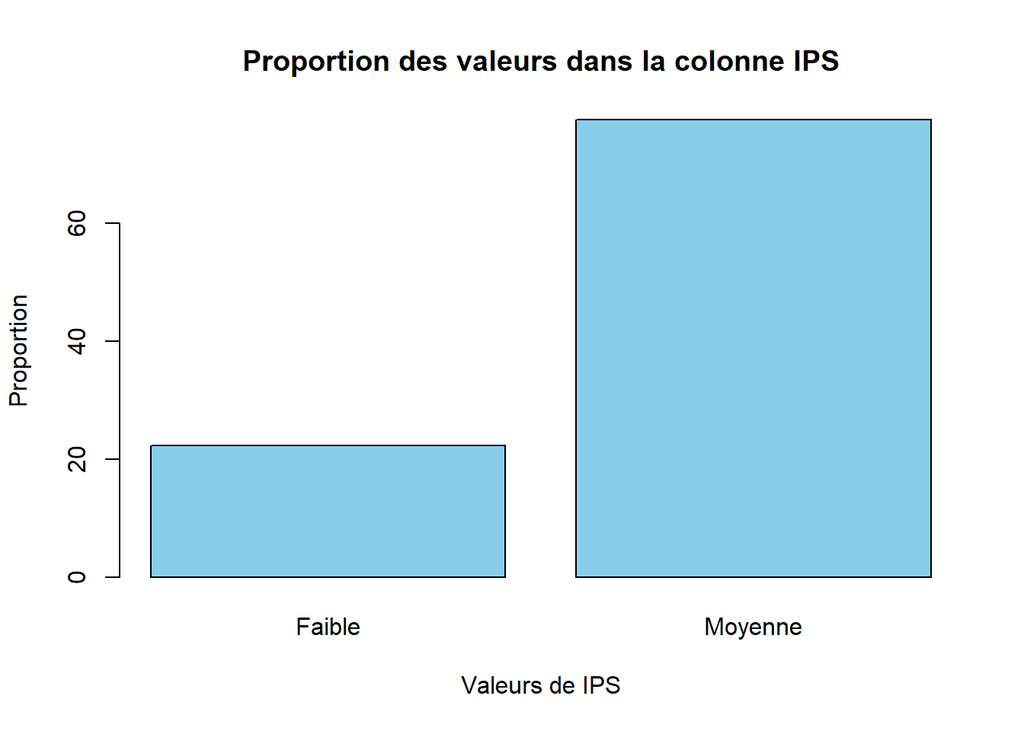

```r
barplot(prop.table(table(data$IPS_categorie))*100, main = "Proportion des valeurs dans la colonne IPS",
        xlab = "Valeurs de IPS", ylab = "Proportion", col = "skyblue")
```

- **Proportion de l’échantillon global de la population selon le milieu géographique**

```r
prop.table(table(data$Géographie))*100
```

```
##
##     rural    urbain
##  1.863354 98.136646
```

| **Milieu géographique** | **urbain** | **rural** |
| --- | --- | --- |
| **Proportion(%)** | 98.14 | 1.86 |

Illustration avec un barplot

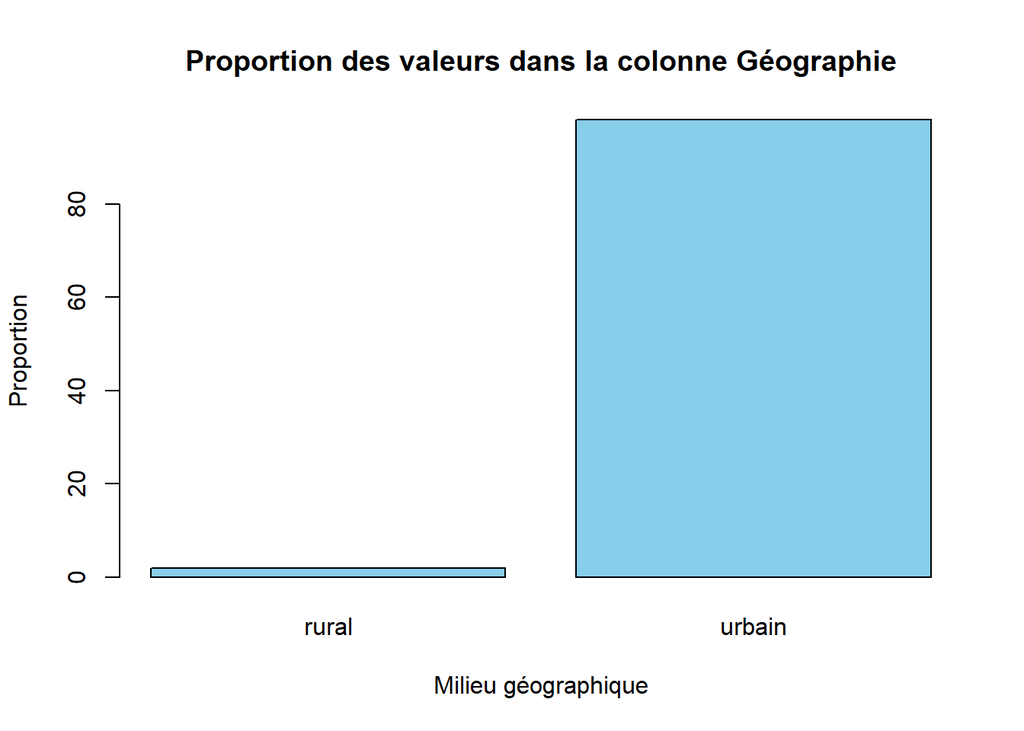

```r
barplot(prop.table(table(data$Géographie))*100, main = "Proportion des valeurs dans la colonne Géographie",
        xlab = "Milieu géographique", ylab = "Proportion", col = "skyblue")
```